# Visualizing data distributions

# 9 Visualizing data distributions

Our first data visualization building block is learning to summarize lists of factors or numeric vectors. Once a vector has been summarized as a distribution, there are several data visualization techniques to effectively relay this information. In this Chapter, we first discuss properties of a variety of distributions and how to visualize distributions

## 9.1 Variable types.

We will be working with two types of variables: categorical and numeric. Each can be divided into two other groups: categorical can be ordinal or not, whereas numerical variables can be discrete or continuous. Keep in mind that discrete numeric data can be considered ordinal.

## 9.2 Case study: describing student heights

We will use data of hights of students.

```r
library(tidyverse)
library(dslabs)
data(heights)
head(heights)
```

|  | sex | height |
| --- | --- | --- |
| 1 | Male | 75 |
| 2 | Male | 70 |
| 3 | Male | 68 |
| 4 | Male | 74 |
| 5 | Male | 61 |
| 6 | Female | 65 |

## 9.3 Distribution function

The most basic statistical summary of a list of objects or numbers is its distribution. When there are more categories, then a simple barplot describes the distribution. When the data is numerical, the task of displaying distributions is more challenging.

## 9.4 Cumulative distribution functions

Numerical data that are not categorical also have distributions. The more useful way to define a distribution for numeric data is to define a function that reports the proportion of the data below a for all possible values of a. This function is called the cumulative distribution function (CDF). F(a) = P(x <= a) ‘Empirical’ is added to make the distinction when data is used.

## 9.5 Histograms

The simplest way to make a histogram is to divide the span of our data into non-overlapping bins of the same size. Then, for each bin, we count the number of values that fall in that interval. What information do we lose? Note that all values in each interval are treated the same when computing bin heights

## 9.6 Smoothed density

The smooth density is basically the curve that goes through the top of the histogram bars when the bins are very, very small. We can actually control the smoothness of the curve that defines the smooth density through an option in the function that computes the smooth density curve. While the histogram is an assumption-free summary, the smoothed density is based on some assumptions.

### 9.6.1 Interpreting the y-axis

Note that interpreting the y-axis of a smooth density plot is not straightforward. The best way to determine the proportion of data in that interval is by computing the proportion of the total area contained in that interval.

### 9.6.2 Densities permit stratification

We point out that an advantage of smooth densities over histograms for visualization purposes is that densities makes it easier to compare two distributions.

## 9.7 Exercises

1. In the `murders` dataset, the region is a categorical variable and the following is its distribution: https://rafalab.github.io/dsbook/book_files/figure-html/barplot-exercise-1.png

To the closet 5%, what proportion of the states are in the North Central region? About 24%

2. Which of the following is true: B

A. The graph above is a histogram. -> It’s a barplot.

B. The graph above shows only four numbers with a bar plot. -> Correct

C. Categories are not numbers, so it does not make sense to graph the distribution. -> We can use barplot to visualize categorical data.

D. The colors, not the height of the bars, describe the distribution. -> The colors do not have any meanings.

3. The plot below shows the eCDF for male heights: https://rafalab.github.io/dsbook/book_files/figure-html/ecdf-exercise-1.png

Based on the plot, what percentage of males are shorter than 75 inches?

B. 95%

4. To the closest inch, what height `m` has the property that 1/2 of the male students are taller than `m` and 1/2 are shorter?

C. 69 inches

5. Here is an eCDF of the murder rates across states: https://rafalab.github.io/dsbook/book_files/figure-html/ecdf-exercise-2-1.png

Knowing that there are 51 states (counting DC) and based on this plot, how many states have murder rates larger than 10 per 100,000 people?

A. 1

6. Based on the eCDF above, which of the following statements are true: D

A. About half the states have murder rates above 7 per 100,000 and the other half below. -> The murder rate is lower than 7 for most of states(96%).

B. Most states have murder rates below 2 per 100,000. -> Only about 25% of the states have murder rates below 2.

C. All the states have murder rates above 2 per 100,000. -> There are some states have murder rates below 2.

D. With the exception of 4 states, the murder rates are below 5 per 100,000. -> Correct. There is 4 escalations in the range of a>5.

7. Below is a histogram of male heights in our `heights` dataset: https://rafalab.github.io/dsbook/book_files/figure-html/height-histogram-exercise-1.png

Based on this plot, how many males are between 63.5 and 65.5?

C. 34

8. About what percentage are shorter than 60 inches?

A. 1%

9. Based on the density plot below, about what proportion of US states have populations larger than 10 million? https://rafalab.github.io/dsbook/book_files/figure-html/density-exercise-1.png

B. 0.15

10. Below are three density plots. Is it possible that they are from the same dataset? https://rafalab.github.io/dsbook/book_files/figure-html/density-exercise-2-1.png

Which of the following statements is true: D

A. It is impossible that they are from the same dataset. -> We can plot differently as we change the degree of smoothness.

B. They are from the same dataset, but the plots are different due to code errors. -> We can plot them on purpose.

C. They are the same dataset, but the first and second plot undersmooth and the third oversmooths. -> The first one might be oversmooth.

D. They are the same dataset, but the first is not in the log scale, the second undersmooths and the third oversmooths. -> Correct.

## 9.8 The normal distribution

We often see the average and standard deviation used as summary statistics. The normal distribution, also known as the bell curve and as the Gaussian distribution, is one of the most famous mathematical concepts in history. Rather than using data, the normal distribution is defined with a mathematical formula. For any interval (a, b), the proportion of values in that interval can be computed using a formula. The distribution is symmetric, centered at the average, and most values (about 95%) are within 2 SDs from the average. If we store the height of males to x:

```r
index <- heights$sex=="Male"
x <- heights$height[index]
```

The average of x is:

```r
m <- sum(x) / length(x)
```

And the standard deviation of x is:

```r
s <- sqrt(sum((x-m)^2) / length(x))
```

Also, we can use pre-bulit functions:

```r
m <- mean(x)
s <- sd(x)
c(average = m, sd = s)
```

```
  average        sd
69.314755  3.611024
```

## 9.9 Standard units

We now will see how well this approximation works at predicting the proportion of values within intervals. For data that is approximately normally distributed, it is convenient to think in terms of standard units as `z = (x - m)/s`. In R, we can obtain standard units using the function `scale`:

```r
z <- scale(x)
```

Now to see how many men are within 2 SDs from the average, we simply type:

```r
mean(abs(z) < 2)
```

```
[1] 0.9495074
```

## 9.10 Quantile-quantile plots

A systematic way to assess how well the normal distribution fits the data is to check if the observed and predicted proportions match. In general, this is the approach of the quantile-quantile plot (QQ-plot). Φ(x)(we call it phi) is the area(=provability) of the interval from negative infinity to x. In R, we can evaluate Φ using the `pnorm` function:

```r
pnorm(-1.96)
```

```
[1] 0.0249979
```

The inversion of Φ(Φ<sup>-1</sup>(x)) gives us the theoretical quantiles for the normal distribution. In R, we can evaluate the inverse of Φ using the `qnorm` function:

```r
qnorm(0.975)
```

```
[1] 1.959964
```

In these cases, the x was the standard normal distribution by default (mean = 0, standard deviation = 1). But we can use any normal distributions by using arguments ‘mean’ and ‘sd’:

```r
qnorm(0.975, mean = 5, sd = 2)
```

```
[1] 8.919928
```

For the normal distribution, all the calculations related to quantiles are done without data, thus the name theoretical quantiles. Using R code, we can define `q` as the value for which `mean(x <= q) = p`:

```r
mean(x <= 69.5)
```

```
[1] 0.5147783
```

To construct a QQ-plot, we do the following: 1. Define a vector of m proportions p<sub>1</sub>,p<sub>2</sub>,…,p<sub>m</sub>. 2. Define a vector of quantiles q<sub>1</sub>,…,q<sub>m</sub> for your data for the proportions p<sub>1</sub>,…,p<sub>m</sub>. We refer to these as the sample quantiles. 3. Define a vector of theoretical quantiles for the proportions p<sub>1</sub>,…,p<sub>m</sub> for a normal distribution with the same average and standard deviation as the data. 4. Plot the sample quantiles versus the theoretical quantiles.

For R code, first we define the vector of propotions:

```r
p <- seq(0.05, 0.95, 0.05)
```

To obtain the quantiles from the data, we can use the function `quantile` like this:

```r
sample_quantiles <- quantile(x, p)
```

To obtain the theoretical normal distribution quantiles with the corresponding average and SD, we use the`function`qnorm:

```r
theoretical_quantiles <- qnorm(p, mean = mean(x), sd = sd(x))
```

To see if they match or not, we plot them against each other and draw the identity line:

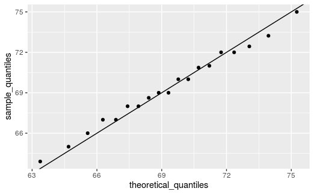

```r
qplot(theoretical_quantiles, sample_quantiles) + geom_abline()
```

Notice that this code becomes much cleaner if we use standard units:

```r
# sample_quantiles <- quantile(z, p)
# theoretical_quantiles <- qnorm(p)
# qplot(theoretical_quantiles, sample_quantiles) + geom_abline()
```

And if we use the function `geom_qq` from ggplot2:

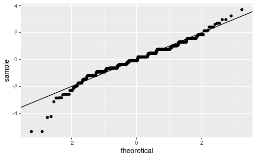

```r
heights %>% filter(sex=="Male") %>%
  ggplot(aes(sample = scale(height))) +
  geom_qq() +
  geom_abline()
```

## 9.11 Percentiles

Percentiles are special cases of quantiles that are commonly used. The percentiles are the quantiles you obtain when setting the p at 0.01,0.02,…,0.99 and we call the case of p = n, the n<sup>th</sup> percentile. If we set p = 0.25, 0.50, 0.75, we call that as quartiles.

## 9.12 Boxplots

Suppose we want to summarize the murder rate distribution, we can quickly see that the normal approximation does not apply here: https://rafalab.github.io/dsbook/book_files/figure-html/hist-qqplot-non-normal-data-1.png